# Causal Cognition: Tutorial 3

## Learning Causal Relationships

### Blicket Experiment: Categorize items based on their Blicketness

(Sobel et al., 2004; Gopnik et al. 2004)

Blicket Detector: $A \& B$ activate detector

**Inference Condition** A alone does not actvate detector.

- Is A a blicket? (6% yes)
- Is B a blicket? (100% yes)

**Blocking Condition** A alone does activate detector.

- Is A a blicket? (99% yes)
- Is B a blicket? (35% yes)

Purely associative learning could not capture these judgements.

More evidence for the transition from Rescorla-Wagner-> Causal-Power -> causal structure induction.

### Generalizing Causal Relationships

Lucas et al., (2014)

Three training objects: A, B, C

Three test objects D, E, F

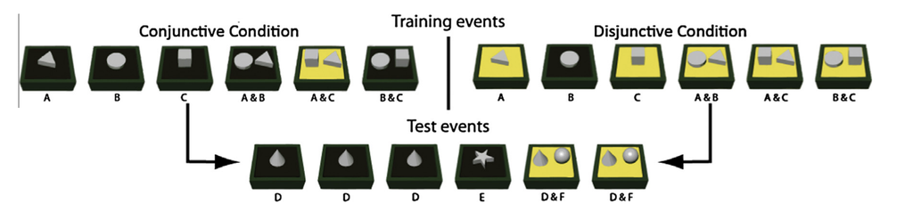

**Which objects in the training phase can be inferred as blickets?**

**How do the training conditions affect inferences in the test phase?**

### Experiment Results

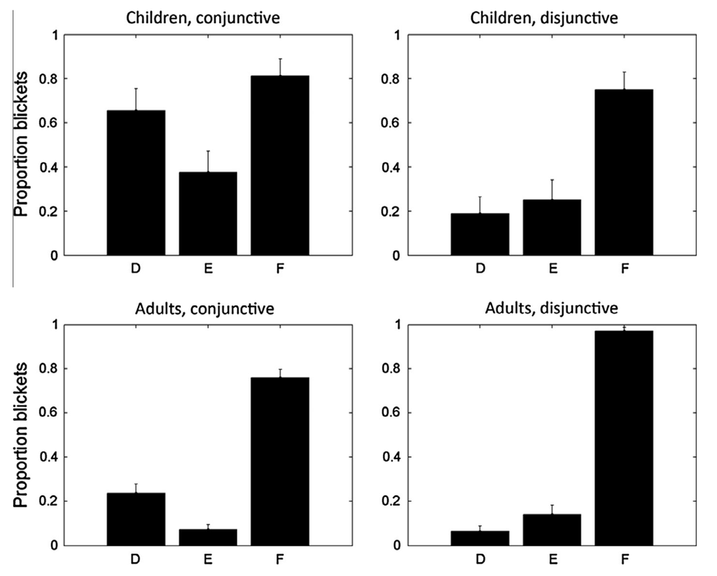

**What do these results suggest with respect to children and adults' causal learning?**

## Modeling the task

### Rescorla-Wagner (Purely associational)

$$ V_{X}^{(n+1)} = V_{X}^{(n)} + \alpha_{X} \beta (\lambda - V_{tot}) $$

- $V_{x}$: strength in predicting outcome from object $X$ (blicket detector in this case)
- $\lambda$ : outcome reward (0 or 1 in this case for blicket detector)
- $\alpha_X$ : salience of $X$ (free-parameter)
- $\beta$: rate parameter (how much we weigh new observations)
- $V_{tot}$ : total prediction

```python
import numpy as np
import matplotlib.pyplot as plt
```

```python
def update_RW(values,objects, alpha=1, beta=0.5,lambda_blicket = 1):

    V_tot = sum([V_x for i,V_x in enumerate(values) if i in objects])
    delta_V = alpha*beta*(lambda_blicket-V_tot)

    return [V_x + (delta_V if i in objects else 0) for i,V_x in enumerate(values) ]
```

```python
objects = [0,1,2]
object_names = ['triangle','circle','cube']
train_objects = [
    [0], # triangle
    [1], # circle
    [2], # cube
    [0,1], # triangle & circle
    [0,2], # triangle & cube
    [1,2], # circle & cube
]

train_outcomes_conj = [0,0,0,0,1,0] # conjunctive blicket detector outcomes
train_outcomes_disj = [1,0,1,1,1,1] # disjunctive blicket detector outcomes


test_names = ['cone','star','sphere']
test_objects = [
    [0], # cone
    [0], # cone
    [0], # cone
    [1], # star
    [0,2], # cone & sphere
    [0,2], # cone & shpere
]
test_outcomes = [0,0,0,0,1,1]
```

```python
n_samples = len(train_objects)
n_objects = len(objects)

vs_disj = np.zeros((n_samples+1,n_objects))
vs_conj = np.zeros((n_samples+1,n_objects))
vs_test = np.zeros((n_samples+1,n_objects))

alpha= .3
beta = .3

for i in range(n_samples):
    vs_conj[i+1] = update_RW(vs_conj[i],train_objects[i],alpha=alpha,beta=beta,lambda_blicket=train_outcomes_conj[i])
    vs_disj[i+1] = update_RW(vs_disj[i],train_objects[i],alpha=alpha,beta=beta,lambda_blicket=train_outcomes_disj[i])
    vs_test[i+1] = update_RW(vs_test[i],test_objects[i],alpha=alpha,beta=beta,lambda_blicket=test_outcomes[i])
```

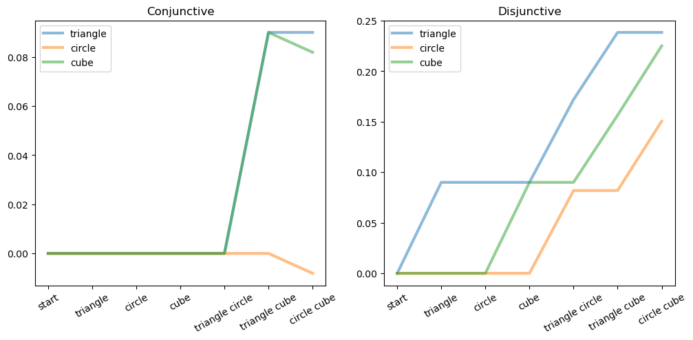

```python
vs = [vs_conj,vs_disj]
xticks = np.arange(len(train_objects)+1)
fig,axes = plt.subplots(nrows=1,ncols=2,figsize=(12,5))
for ax_i,ax in enumerate(axes):
    for i in range(n_objects):
        ax.plot(xticks,vs[ax_i][:,i],ls='-',alpha=.5,label=object_names[i],lw=3)
        ax.legend()
    ax.set_xticks(xticks)
    ax.set_title('Conjunctive' if ax_i==0 else 'Disjunctive')
    ax.set_xticklabels(['start']+[' '.join([object_names[x] for x in train_object]) for train_object in train_objects],rotation=30)
```

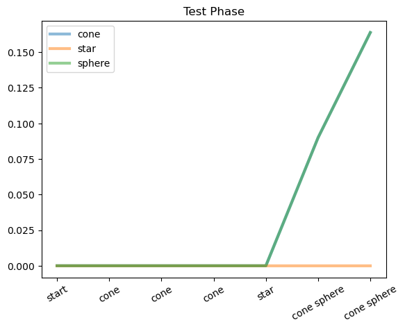

```python
fig,ax = plt.subplots()
xticks = np.arange(len(train_objects)+1)
for i in range(n_objects):
    ax.plot(vs_test[:,i],ls='-',alpha=.5,label=test_names[i],lw=3)
ax.legend()
ax.set_xticks(xticks)
ax.set_xticklabels(['start']+[' '.join([test_names[x] for x in test_object]) for test_object in test_objects],rotation=30)
ax.set_title('Test Phase')
plt.show()
```

## Activity

Test your partner's hypothesis generalization of blicketness. In this activity you will pretend to be experimenters and participants, looking to see how well people generalize causal relationships from experiments.

**Procedure**

*Experimenter:*

From three objects (A,B,C), select *at least* one to be a blicket (and keep it a secret).

Then, you must pick a blicket machine:

- Disjunctive (any blicket will make the machine go off)
- Conjunctive (requires two blickets for the machine to go off)
- Anything more complex
  - exactly 1 or 2 blickets
  - Blicket and a non Blicket (mean one)
  - etc.

Keep in mind that if your detecter requires 2 or 3 blickets then you should have at least that many blickets in your three objects (to be nice).

*Participant*

Your job as is to determine what objects are blickets, and if you can guess what makes the detector go off.

**You have 6 experiments you can conduct** selecting any set of the objects and place them on the machine. The experimenter will tell you if the detector turns on.

I recommend you write down your experiments.

Then the experimenter will ask 2 questions which the participant must answer:

1. What objects are blickets?
2. What makes the blicket detector go off?